# Making the Data Ready for Business

Phase 1 — Preprocessing and Feature Engineering

Author

Charan Malampati, Arjun, Rahul, Sushant | IIIT Kottayam | DWDM Course Project

Published

April 8, 2026

## 1 Before the Analysis, the Data Must Be Trusted

Any business insight is only as good as the data behind it.

Before we can ask *why deliveries are late* or *how long an order will take*, we need to be certain the dataset is accurate, consistent, and structured in a way that reflects real-world operations. Raw data almost never is.

This phase documents every transformation applied to the raw Zomato food delivery dataset — from messy, inconsistent records to a clean, model-ready table the business can rely on.

## 2 What We Started With

The raw dataset — `Zomato_Dataset.csv` — captures the full lifecycle of a delivery order: who placed it, which restaurant handled it, what conditions the rider faced, and how long it actually took.

It arrived with common real-world problems: inconsistent column naming, columns stored as the wrong type, missing values, duplicate rows, and raw GPS coordinates instead of usable distances.

```r
tibble(
  Dimension = c("Rows (orders)", "Columns (variables)"),
  Value = c(format(nrow(df), big.mark = ","), ncol(df))
) |> kbl_nice("Dataset dimensions after cleaning")
```

Dataset dimensions after cleaning

| Dimension | Value |
| --- | --- |
| Rows (orders) | 40,036 |
| Columns (variables) | 29 |

```r
glimpse(df)
```

```
Rows: 40,036
Columns: 29
$ id                          <chr> "0xd987", "0x2784", "0xc8b6", "0xdb64", "0…
$ delivery_person_id          <chr> "KOCRES16DEL01", "PUNERES13DEL03", "LUDHRE…
$ delivery_person_age         <dbl> 21, 23, 34, 24, 29, 34, 21, 31, 37, 33, 29…
$ delivery_person_ratings     <dbl> 4.7, 4.7, 4.3, 4.7, 4.5, 4.9, 4.7, 4.7, 5.…
$ restaurant_latitude         <dbl> 10.00306, 18.56245, 30.89958, 26.46350, 19…
$ restaurant_longitude        <dbl> 76.30759, 73.91662, 75.80935, 80.37293, 72…
$ delivery_location_latitude  <dbl> 10.04306, 18.65245, 30.91958, 26.59350, 19…
$ delivery_location_longitude <dbl> 76.34759, 74.00662, 75.82935, 80.50293, 72…
$ order_date                  <date> 2022-02-13, 2022-03-04, 2022-02-13, 2022-…
$ time_orderd                 <chr> "0-01-01T14:55:00Z", "0-01-01T17:30:00Z", …
$ time_order_picked           <chr> "0-01-01T15:05:00Z", "0-01-01T17:40:00Z", …
$ weather_conditions          <chr> "Stormy", "Sandstorms", "Sandstorms", "Fog…
$ road_traffic_density        <chr> "High", "Medium", "Low", "Jam", "Jam", "Ja…
```

[output cut: 16 more lines]

Before any analysis could begin, these issues needed to be resolved. Each decision below was made with one goal: produce a dataset the business can trust.

## 3 Step 1 — Standardise Column Names

Raw data arrived with mixed capitalisation, spaces in names, and inconsistent conventions. These cause silent bugs in code and make collaboration harder.

All column names were converted to clean `snake_case` using `janitor::clean_names()`.

```r
colnames(df) |>
  as_tibble() |>
  rename(Column = value) |>
  kbl_nice("Cleaned column names — consistent snake_case throughout")
```

Cleaned column names — consistent snake_case throughout

| Column |
| --- |
| id |
| delivery_person_id |
| delivery_person_age |
| delivery_person_ratings |
| restaurant_latitude |
| restaurant_longitude |
| delivery_location_latitude |
| delivery_location_longitude |
| order_date |
| time_orderd |
| time_order_picked |
| weather_conditions |
| road_traffic_density |
| vehicle_condition |
| type_of_order |
| type_of_vehicle |
| multiple_deliveries |
| festival |
| city |
| time_taken_min |
| distance_km |
| pickup_delay_min |
| order_hour |
| order_day_of_week |
| order_month |
| is_weekend |
| age_group |
| is_rush_hour |
| road_traffic_density_ord |

> **Why it matters:** Consistent naming means every analyst, script, and report refers to the same variable the same way. No more `Time.Taken` vs `time taken` vs `TimeTaken`.

## 4 Step 2 — Fix Data Types

Several columns arrived as the wrong type. Age was a string. Ratings had decimal noise. Timestamps were plain text. `time_taken_min` was stored as `"(min) 30"` — a mixed string — and needed the number extracted with `str_extract()`.

```r
tibble(
  Column = c(
    "delivery_person_age", "delivery_person_ratings",
    "multiple_deliveries", "vehicle_condition",
    "time_taken_min", "order_date",
    "time_orderd", "time_order_picked"
  ),
  `Raw Type` = c(rep("character", 8)),
  `Corrected Type` = c(
    "numeric", "numeric", "numeric", "numeric",
    "numeric (extracted)", "Date",
    "datetime (parsed)", "datetime (parsed)"
  ),
  `Why It Matters` = c(
    "Age must be numeric for binning and regression",
    "Ratings must be numeric for correlation and modelling",
    "Delivery count must be integer for aggregation",
    "Condition score must be numeric for ordering",
    "Target variable — must be a clean number, not a string",
    "Date enables day-of-week, month, and weekend extraction",
    "Order time enables pickup delay calculation",
    "Pickup time enables pickup delay calculation"
  )
) |>
  kbl(caption = "Type corrections applied during preprocessing") |>
  kable_styling(full_width = TRUE, bootstrap_options = c("striped", "hover"))
```

Type corrections applied during preprocessing

| Column | Raw Type | Corrected Type | Why It Matters |
| --- | --- | --- | --- |
| delivery_person_age | character | numeric | Age must be numeric for binning and regression |
| delivery_person_ratings | character | numeric | Ratings must be numeric for correlation and modelling |
| multiple_deliveries | character | numeric | Delivery count must be integer for aggregation |
| vehicle_condition | character | numeric | Condition score must be numeric for ordering |
| time_taken_min | character | numeric (extracted) | Target variable — must be a clean number, not a string |
| order_date | character | Date | Date enables day-of-week, month, and weekend extraction |
| time_orderd | character | datetime (parsed) | Order time enables pickup delay calculation |
| time_order_picked | character | datetime (parsed) | Pickup time enables pickup delay calculation |

> **Why it matters:** A model given ratings or age as text will either crash or silently encode them wrong. Correct types are the foundation of correct analysis.

## 5 Step 3 — Remove Duplicates

Duplicate rows inflate order counts, distort averages, and can cause models to overfit to repeated records. Deduplication was applied with `dplyr::distinct()` immediately after type conversion.

> **The case we have here:** Here, the dataset is pretty without any duplicates before hand, and that’s a good thing. **Why it matters:** Every row in the final dataset represents one real, unique delivery. No order is counted twice.

## 6 Step 4 — Handle Missing Values

Missing values were handled differently depending on the column’s role:

```r
missing_summary <- df |>
  summarise(across(everything(), ~ sum(is.na(.)))) |>
  pivot_longer(everything(), names_to = "Column", values_to = "Missing Count") |>
  mutate(`Missing %` = round(100 * `Missing Count` / nrow(df), 2)) |>
  filter(`Missing Count` > 0) |>
  arrange(desc(`Missing Count`))

if (nrow(missing_summary) == 0) {
  cat("No missing values remain in the cleaned dataset.")
} else {
  missing_summary |>
    kbl_nice("Remaining missing values after preprocessing")
}
```

Remaining missing values after preprocessing

| Column | Missing Count | Missing % |
| --- | --- | --- |
| time_orderd | 5013 | 12.52 |
| order_hour | 5013 | 12.52 |
| is_rush_hour | 5013 | 12.52 |
| time_order_picked | 3473 | 8.67 |

```r
tibble(
  `Column Type` = c(
    "Target variable (time_taken_min)",
    "Numeric features (age, ratings, vehicle condition)",
    "Categorical features (weather, traffic, city, festival)"
  ),
  `Strategy` = c(
    "Rows with missing target dropped entirely",
    "Imputed with column median",
    "Imputed with column mode (most frequent value)"
  ),
  `Reasoning` = c(
    "A row without a delivery time cannot be used for training or evaluation",
    "Median is robust to skew — not pulled by extreme outliers the way mean is",
    "Mode preserves the most common real-world category for each variable"
  )
) |>
  kbl(caption = "Missing value strategy — one clear rule per column type") |>
  kable_styling(full_width = TRUE, bootstrap_options = c("striped", "hover"))
```

Missing value strategy — one clear rule per column type

| Column Type | Strategy | Reasoning |
| --- | --- | --- |
| Target variable (time_taken_min) | Rows with missing target dropped entirely | A row without a delivery time cannot be used for training or evaluation |
| Numeric features (age, ratings, vehicle condition) | Imputed with column median | Median is robust to skew — not pulled by extreme outliers the way mean is |
| Categorical features (weather, traffic, city, festival) | Imputed with column mode (most frequent value) | Mode preserves the most common real-world category for each variable |

> **Why it matters:** Imputing with median and mode keeps the dataset representative of real operations. Dropping rows with unknown delivery times is the only honest choice — guessing them would corrupt the model’s training signal.

## 7 Step 5 — Remove Outliers

Outliers in the target variable and key numeric features were identified and removed using the **IQR method** (1.5 × interquartile range fence).

```r
tibble(
  Column = c("time_taken_min", "delivery_person_age", "delivery_person_ratings"),
  `Outlier Rule` = rep("Remove values outside Q1 − 1.5×IQR and Q3 + 1.5×IQR", 3),
  `Why` = c(
    "Delivery times of 90+ min are likely logging errors or extreme edge cases",
    "Age values outside the plausible 15–45 range suggest data entry problems",
    "Rating extremes outside the valid scale are unreliable and noisy"
  )
) |>
  kbl(caption = "Outlier treatment applied using IQR fences") |>
  kable_styling(full_width = TRUE, bootstrap_options = c("striped", "hover"))
```

Outlier treatment applied using IQR fences

| Column | Outlier Rule | Why |
| --- | --- | --- |
| time_taken_min | Remove values outside Q1 − 1.5×IQR and Q3 + 1.5×IQR | Delivery times of 90+ min are likely logging errors or extreme edge cases |
| delivery_person_age | Remove values outside Q1 − 1.5×IQR and Q3 + 1.5×IQR | Age values outside the plausible 15–45 range suggest data entry problems |
| delivery_person_ratings | Remove values outside Q1 − 1.5×IQR and Q3 + 1.5×IQR | Rating extremes outside the valid scale are unreliable and noisy |

> **Why it matters:** A model trained on extreme outliers skews its predictions toward exceptional cases. Removing them makes the model useful for the typical order the business actually handles every day.

## 8 Step 6 — Engineer Features That Reflect Operations

The most important step. Raw GPS coordinates and timestamps are not useful to a predictive model. We transform them into features that reflect actual operational decisions.

### 8.1 Distance from Coordinates

Four raw coordinate columns (`restaurant_latitude`, `restaurant_longitude`, `delivery_location_latitude`, `delivery_location_longitude`) were compressed into a single **Haversine distance in kilometres** — the geodesic distance between the restaurant and the delivery address.

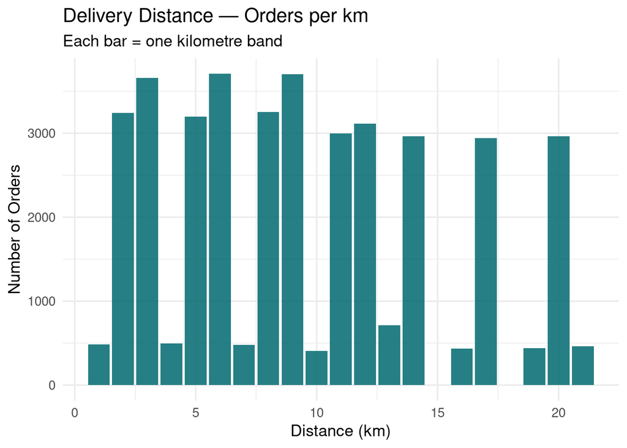

Distribution of Haversine delivery distances — engineered from raw GPS coordinates

```r
df |>
  filter(!is.na(distance_km), distance_km > 0) |>
  mutate(dist_rounded = round(distance_km)) |>
  count(dist_rounded) |>
  filter(dist_rounded <= 25) |>
  ggplot(aes(x = dist_rounded, y = n)) +
  geom_col(fill = "#01696f", alpha = 0.85) +
  labs(
    title = "Delivery Distance — Orders per km",
    subtitle = "Each bar = one kilometre band",
    x = "Distance (km)", y = "Number of Orders"
  ) +
  theme_minimal(base_size = 13)
```

> Four coordinate columns became one operationally meaningful number. The model uses distance, not raw GPS values.

### 8.2 Pickup Delay

The time between `time_orderd` and `time_order_picked` was calculated directly from the two parsed timestamp columns. Negative values (midnight-crossing orders) were adjusted by adding 1440 minutes.

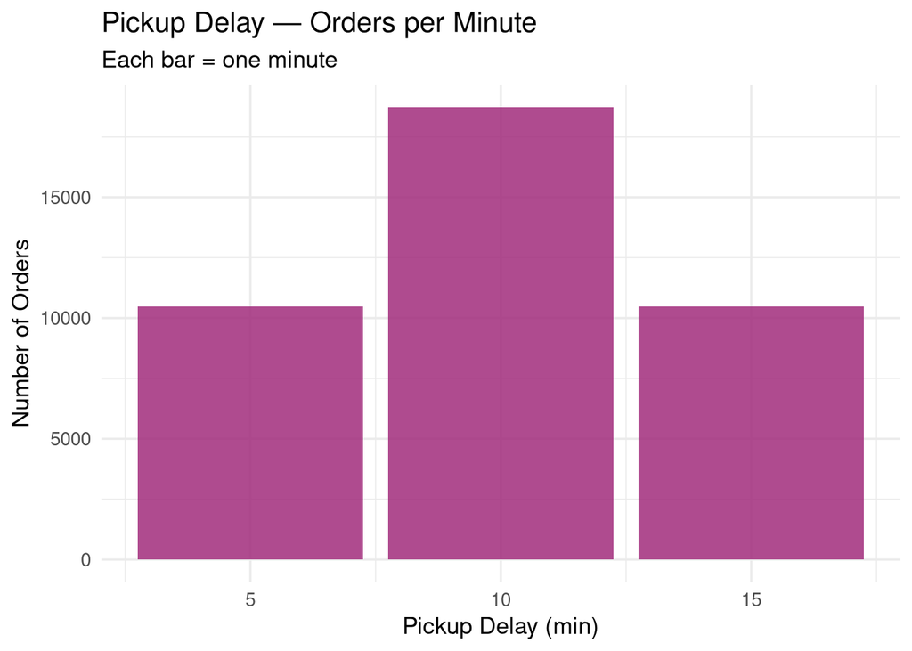

Distribution of pickup delay — the hidden bottleneck between order and dispatch

```r
df |>
  filter(!is.na(pickup_delay_min), pickup_delay_min >= 0) |>
  mutate(pickup_delay_min = round(pickup_delay_min)) |>
  count(pickup_delay_min) |>
  filter(pickup_delay_min <= 30) |>
  ggplot(aes(x = pickup_delay_min, y = n)) +
  geom_col(fill = "#a12c7b", alpha = 0.85) +
  labs(
    title = "Pickup Delay — Orders per Minute",
    subtitle = "Each bar = one minute",
    x = "Pickup Delay (min)", y = "Number of Orders"
  ) +
  theme_minimal(base_size = 13)
```

> This feature turned out to be one of the strongest predictors in the modelling phase. It would not exist if timestamps were left in raw form.

### 8.3 Time-Based Features

The order timestamp and date were decomposed into five operational signals:

```r
tibble(
  `Engineered Feature` = c(
    "order_hour", "order_day_of_week", "order_month",
    "is_weekend", "is_rush_hour"
  ),
  `Derived From` = c(
    "time_orderd (hour component)",
    "order_date (weekday)",
    "order_date (month)",
    "order_date — 1 if Saturday or Sunday",
    "order_hour — 1 if 7–9am, 12–2pm, or 6–9pm"
  ),
  `Business Meaning` = c(
    "Which hour has the slowest average delivery?",
    "Are weekday and weekend operations different?",
    "Do seasonal patterns affect delivery performance?",
    "Does weekend staffing differ from weekday?",
    "Are peak demand windows adequately covered?"
  )
) |>
  kbl(caption = "Five temporal features extracted from timestamps and order date") |>
  kable_styling(full_width = TRUE, bootstrap_options = c("striped", "hover"))
```

Five temporal features extracted from timestamps and order date

| Engineered Feature | Derived From | Business Meaning |
| --- | --- | --- |
| order_hour | time_orderd (hour component) | Which hour has the slowest average delivery? |
| order_day_of_week | order_date (weekday) | Are weekday and weekend operations different? |
| order_month | order_date (month) | Do seasonal patterns affect delivery performance? |
| is_weekend | order_date — 1 if Saturday or Sunday | Does weekend staffing differ from weekday? |
| is_rush_hour | order_hour — 1 if 7–9am, 12–2pm, or 6–9pm | Are peak demand windows adequately covered? |

### 8.4 Rider Age Bins

```r
df |>
  filter(!is.na(age_group)) |>
  count(`Age Group` = age_group) |>
  mutate(`% of Riders` = paste0(round(100 * n / sum(n), 1), "%")) |>
  kbl_nice("Rider age distribution across the workforce")
```

Rider age distribution across the workforce

| Age Group | n | % of Riders |
| --- | --- | --- |
| 15-20 | 1973 | 4.9% |
| 21-25 | 10038 | 25.1% |
| 26-30 | 11715 | 29.3% |
| 31-35 | 8990 | 22.5% |
| 36-40 | 7320 | 18.3% |

### 8.5 Traffic Ordinal Encoding

Traffic density was encoded as an ordered integer (1–4) because it has a natural, meaningful progression:

```r
tibble(
  `Traffic Label` = c("Low", "Medium", "High", "Jam"),
  `Encoded Value` = c(1L, 2L, 3L, 4L),
  `Reasoning` = c(
    "Least congested — baseline condition",
    "Moderate — some slowdown expected",
    "Significant congestion — noticeable delay",
    "Worst condition — maximum delay"
  )
) |>
  kbl_nice("Ordinal encoding preserves the natural order of traffic severity")
```

Ordinal encoding preserves the natural order of traffic severity

| Traffic Label | Encoded Value | Reasoning |
| --- | --- | --- |
| Low | 1 | Least congested — baseline condition |
| Medium | 2 | Moderate — some slowdown expected |
| High | 3 | Significant congestion — noticeable delay |
| Jam | 4 | Worst condition — maximum delay |

> **Why ordinal, not one-hot?** Because the order matters. Jam is strictly worse than High. Ordinal encoding captures that in a single column instead of creating four redundant binary columns.